# CARET: Predict EW Volume BV’s with LGEP: SNPs 012

Adam Festa

6/10/2018

## 0.1 Load data

- First, load the –012 output produced during the SNP filtering.
- File loaded below has no missing snps, MAF > .05, and are of at least Q30.
- Additionally, the data frame contains rownames for bioloigcal samples and colnames as snp name/position

```r
load("/mnt/bio.012.df.RData")
```

- Now load the phenotypes

```r
## Load phenotype data ####
#load("~/Documents/Grad_Projects/Breeding-Value-Prediction/disk6directory/resources/expt.dat.720.RData")
load("/mnt/Breeding-Value-Prediction/disk6directory/resources/expt.dat.720.RData")
expt.dat.720$animal_id <- as.character(expt.dat.720$animal_id)
expt.dat.720$fam_id <- as.character(expt.dat.720$fam_id)
expt.dat.720$batch <- as.character(expt.dat.720$batch)

# Create bio phenos from individuals with no missing Volume and who have unique, fam*animal*batch*vol combo
bio.phenos <- unique(expt.dat.720[which(!is.na(expt.dat.720$Volume) ==T),c("fam_id","animal_id","batch","Volume")])
```

- The bio phenos animal id and 012 matrix have the same style names but are not in the same order. Match 012 genos to phenotype data

```r
# Index the snp data frame to only include individuals which have phenotypes
keep.index <-  which(rownames(bio.012.df) %in% bio.phenos$animal_id)

# Keep only those rows
bio.012.df <- bio.012.df[keep.index,]

bio.phenos <- bio.phenos[which(bio.phenos$animal_id %in% rownames(bio.012.df)),]
identical(bio.phenos$animal_id[match(rownames(bio.012.df),bio.phenos$animal_id)],rownames(bio.012.df))
```

```
## [1] TRUE
```

```r
bio.phenos <- bio.phenos[match(rownames(bio.012.df),bio.phenos$animal_id),]
rownames(bio.phenos) <- bio.phenos$animal_id
rm(keep.index)
```

## 0.2 Generate family-level data

- Generate family phenos

```r
fam.phenos <- unique(bio.phenos[,c("fam_id","Volume")])
rownames(fam.phenos) <- fam.phenos$fam_id
u.fams <- unique(fam.phenos$fam_id)
```

- The family mean SNP matrix was generated once using the FULL bio 012 matrix and then saved. It’s loaded here

```r
load("/mnt/fam.012.df.RData")
```

## 0.3 Create test/train matricies

- Some of the filtering methods will use phenotypes, while others will not, but we can go ahead and split the LGEP and EW into train/test for those filtering methods that do use phenos

```r
# Identify crossover families between batches
crossover.fams <- unique(bio.phenos[,c("fam_id","Volume","batch")])
crossover.fams <- names(which(table(crossover.fams$fam_id) ==2))

# Subset the unique list of families that are in the LGEP or EW
ew.fams <- unique(bio.phenos$fam_id[which(bio.phenos$batch == "EW")])
lgep.fams <- unique(bio.phenos$fam_id[which(bio.phenos$batch == "LGEP")])

# Remove LGEP families from the EW families (i.e. remove crossover families)
ew.fams <- ew.fams[-which(ew.fams %in% crossover.fams)]

# Create a training set from the biological replicates using the lgep and ew families
train.p.bio <- bio.phenos$Volume[which(bio.phenos$fam_id %in% lgep.fams)]
train.dat.bio <- bio.012.df[which(bio.phenos$fam_id %in% lgep.fams),]
#colnames(train_d.bio) <- 1:ncol(train.dat)
```

- The object `train.dat.bio` now contains the LGEP 012 output and the `bio.012.df` object contains the full 189 biological replicates.

## 0.4 Apply filters

- Apply caret filters including:
  - ANOVA scores: These are generated using phenotypes, so only the LGEP will be used to identify a subset to predict
  - BCV: This may be generated without phenotypes, so the whole dataset will be used.
  - nearzerovar: This may also be used without phenotypes, so the whole dataset will be used.

### 0.4.1 Generate anova scores

- Use caret package to generate anova scores with the LGEP 012 counts and phenos (i.e. `train.dat` & `train.phenos` objects)

```
# Using the biological replicate training set, apply anovaScores to each SNP
LGEP.anova.scores <- unlist(mclapply(1:ncol(train.dat.bio), function(each.col){
  anovaScores(x = train.dat.bio[,each.col],y = train.p.bio)},mc.cores=32))
save(LGEP.anova.scores,file="/mnt/LGEP.anova.scores.RData",compress = T)
```

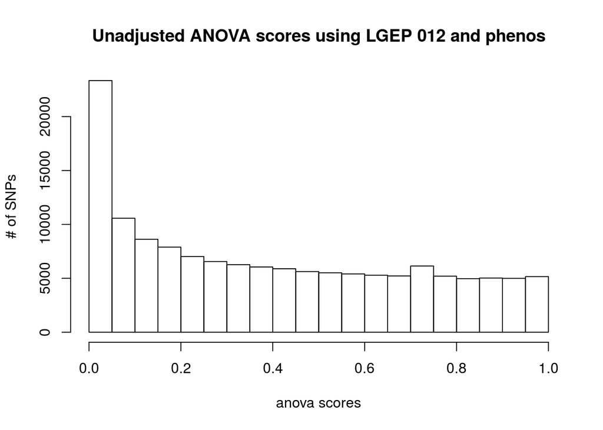

```r
load("/mnt/LGEP.anova.scores.RData")
# Generate a histogram of these anova scores
hist(LGEP.anova.scores, main="Unadjusted ANOVA scores using LGEP 012 and phenos",xlab ="anova scores",ylab="# of SNPs")
```

```r
# How many of anova scores are less than .05 (unadjusted)
length(which(LGEP.anova.scores < .05))
```

```
## [1] 23344
```

```r
# How many of anova scores are less than .05 (adjusted)
length(which(p.adjust(LGEP.anova.scores) < .05))
```

```
## [1] 88
```

### 0.4.2 Filter BCV

- Here we will use the whole 012 data set to identify SNPs who have high BCV relative to all samples (BCV= sd/mean)

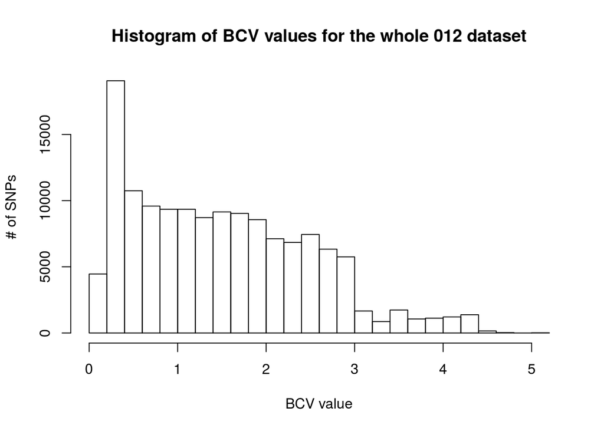

```r
# Estimate the variance, sd, mean, and bcv for each SNP
var.snps <- apply(bio.012.df,2,var)
sd.snps <- apply(bio.012.df,2,sd)
mean.snps <- apply(bio.012.df,2,mean)
bcv.snps <- sd.snps/mean.snps

# Take a look at the distribution of bcv values
hist(bcv.snps,main = "Histogram of BCV values for the whole 012 dataset",xlab="BCV value",ylab="# of SNPs")
```

```r
length(which(bcv.snps > 3))
```

```
## [1] 9219
```

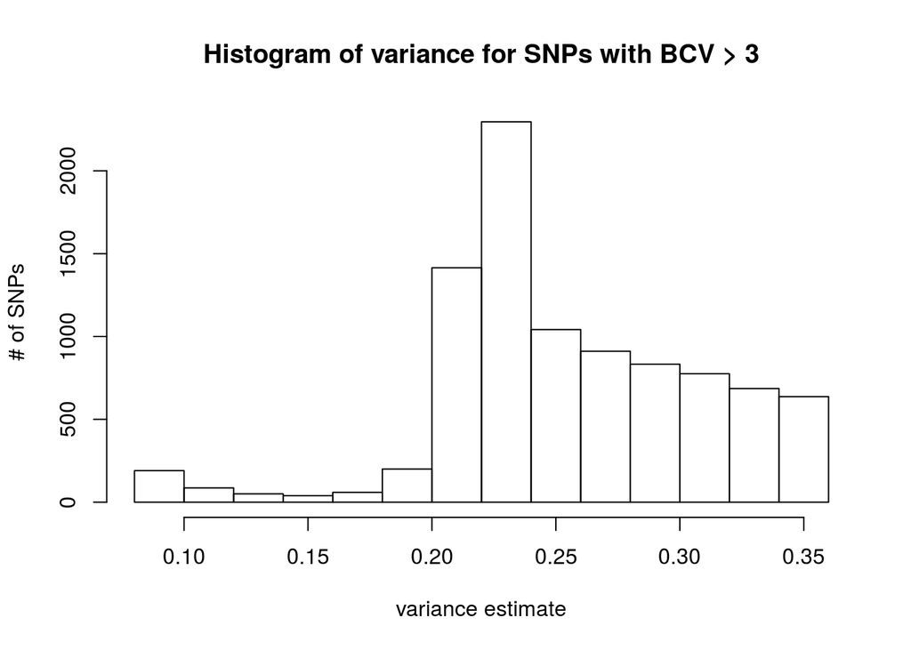

```r
# Look at the histogram of variance using only those SNPs with bcv > 3
hist(var.snps[which(bcv.snps > 3)],main="Histogram of variance for SNPs with BCV > 3",xlab = "variance estimate",ylab = "# of SNPs")
```

```r
length(which(var.snps[which(bcv.snps > 3)] < .2))
```

```
## [1] 624
```

```r
interesting.bcv.snps <- which(var.snps[which(bcv.snps > 3)] < .2)
```

- A total of 9,219 SNPs have BCV values greater than 3.
- There is an interesting set of 624 SNPs which have a BCV greater than 3 but variance less than 0.2

### 0.4.3 Filter the nearzerovar

```r
# This near zero var will check for things which have less than 10 or less unique values and 95/5 most common/least common (19:1 ratio)
check.vars <- nearZeroVar(x = bio.012.df,allowParallel = T)

# How many did not meet these thresholds?
length(check.vars)
```

```
## [1] 6624
```

```r
## 6,624 SNPs did not meet threshold
```

- A total of 6624 SNPs did not meet this threshold, let’s take a look at their BCV values

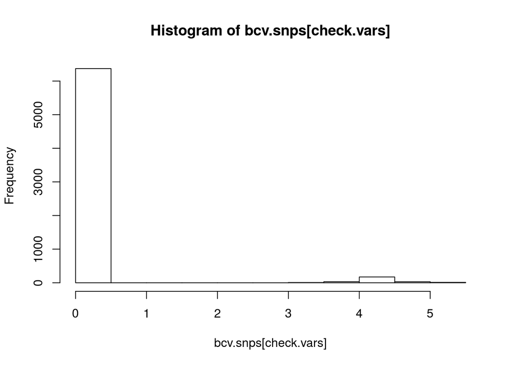

```r
hist(bcv.snps[check.vars])
```

- There is an odd set which have > 3 BCV. Let’s subset those out too.

```r
near.zero.bcv3.snps <- check.vars[which(bcv.snps[check.vars] > 3)]
length(near.zero.bcv3.snps)
```

```
## [1] 253
```

- A total of 253 SNPs were identified as being removed by the nearzerovar BUT they had BCV > 3. We will keep those for further inspection.
- Do these 253 SNPs show up as significant in the p-adjusted anova scores on the full data?

```r
summary(p.adjust(LGEP.anova.scores)[check.vars])
```

```
##    Min. 1st Qu.  Median    Mean 3rd Qu.    Max.
##       1       1       1       1       1       1
```

- No, none of these 253 were identified as being associated with the LGEP
- How do the variance of these SNPs look?

```r
summary(var.snps[near.zero.bcv3.snps])
```

```
##    Min. 1st Qu.  Median    Mean 3rd Qu.    Max.
##  0.1434  0.1824  0.1824  0.1796  0.1824  0.2150
```

- The SNP variance’s are all pretty small. We will still keep this set and use during prediction.

## 0.5 Caret pt1: Pressure test multiple models ANOVA < .05

- We have 3 various filters to work with including:
  - Anova scores generated using ONLY LGEP
  - BCV values generated using ALL data
  - Nearzerovar subset identified with ALL data (BCV > 3)
- In this section, we will run all *faster* models on the training set (LGEP families) and look at which models tend to perform best in terms of `R2` & `rmse`

### 0.5.1 Run all *faster* models on LGEP training

- The LGEP and EW are split into train and test using a specific pvalue which will subset SNPs based on their adjusted pval scores

```r
pval <- .05
LGEP.train.dat <- fam.012.df[which(fam.phenos$fam_id %in% lgep.fams),which(p.adjust(LGEP.anova.scores) < pval)]
colnames(LGEP.train.dat) <- colnames(fam.012.df[,which(p.adjust(LGEP.anova.scores) < pval)])
EW.test.dat <- fam.012.df[which(fam.phenos$fam_id %in% ew.fams),which(p.adjust(LGEP.anova.scores) < pval)]
colnames(EW.test.dat) <- colnames(fam.012.df[,which(p.adjust(LGEP.anova.scores) < pval)])
LGEP.train.p <- fam.phenos$Volume[which(fam.phenos$fam_id %in% lgep.fams)]
EW.test.p <- fam.phenos$Volume[which(fam.phenos$fam_id %in% ew.fams)]
```

- Set up a LOOCV training method for the LGEP and conduct a grid search across parameters of 12 different models.

```
tC <- trainControl(method="LOOCV",allowParallel = T, savePredictions="all",verboseIter = TRUE,search="grid")
algorithmList <- c("glmnet","pls","bagEarth","bagEarthGCV","cforest","gaussprRadial","knn","penalized","ranger","RRFglobal","svmLinear2","svmRadialCost")

t2 <- lapply(algorithmList,function(i){
    set.seed(123)
     t2 <- train(y=LGEP.train.p, x=LGEP.train.dat, (i), trControl = tC)
     })
save(t2,file="/mnt/anova.05.LGEP.EW.RData")
```

- Extract results from the list and display in table

```r
algorithmList <- c("glmnet","pls","bagEarth","bagEarthGCV","cforest","gaussprRadial","knn","penalized","ranger","RRFglobal","svmLinear2","svmRadialCost")
load("/mnt/anova.05.LGEP.EW.RData")
create.data.table()
```

| Num | Name | R^2 | RMSE | time [s] | Model name |
| --- | --- | --- | --- | --- | --- |
| 1 | glmnet | 0.141864932400158 | 7.86912621791418 | 3.28999999999996 | glmnet |
| 2 | pls | 0.662642803010506 | 7.70813497381736 | 1.42699999999968 | Partial Least Squares |
| 3 | bagEarth | 0.368815982091161 | 8.77299269277747 | 111.678 | Bagged MARS |
| 4 | bagEarthGCV | 0.624386219369759 | 8.81131363132629 | 42.2610000000004 | Bagged MARS using gCV Pruning |
| 5 | cforest | 0.450626259867692 | 11.0960971974813 | 17.0529999999999 | Conditional Inference Random Forest |
| 6 | gaussprRadial | 0.742464776138352 | 9.49134868308172 | 1.43499999999949 | Gaussian Process with Radial Basis Function Kernel |
| 7 | knn | 0.655723901724318 | 9.36943900842425 | 1.08100000000013 | k-Nearest Neighbors |
| 8 | penalized | 0.696887788088812 | 7.53582379014324 | 21.6630000000005 | Penalized Linear Regression |
| 9 | ranger | 0.625251315922936 | 8.66536697794752 | 19.7689999999993 | Random Forest |
| 10 | RRFglobal | 0.39273294703161 | 8.70295586388799 | 50.1869999999999 | Regularized Random Forest |

[output cut: 2 more lines]

### 0.5.2 Performance on EW test set

- Use each model to predict the EW and then display results

```r
results.cor <- unlist(lapply(t2,function(i){cor(predict(i,EW.test.dat),EW.test.p)}))
```

```
## geom_path: Each group consists of only one observation. Do you need to
## adjust the group aesthetic?
```

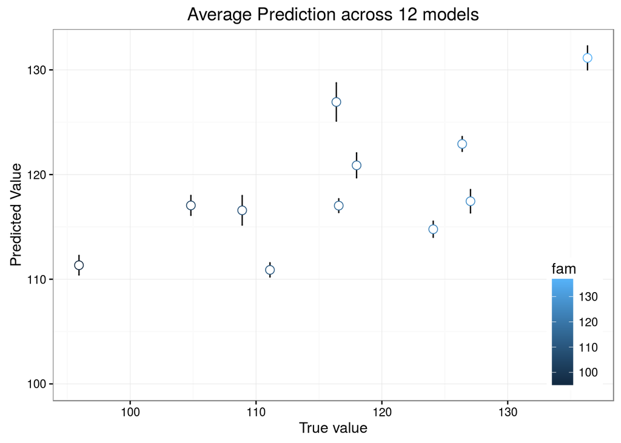

```r
results.rmse <- unlist(lapply(t2,function(i){RMSE(pred = predict(i,EW.test.dat),obs = EW.test.p)}))

plot.mean.model.preds()
```

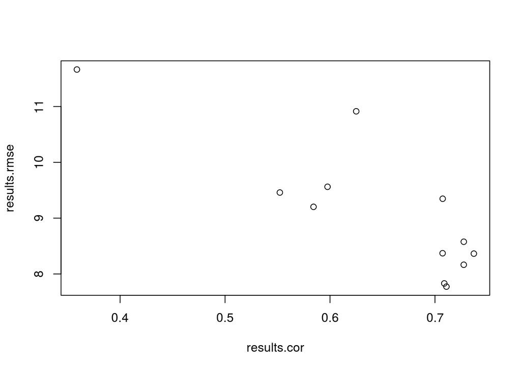

```r
plot(results.cor,results.rmse)
```

```r
which.min(results.rmse)
```

```
## [1] 3
```

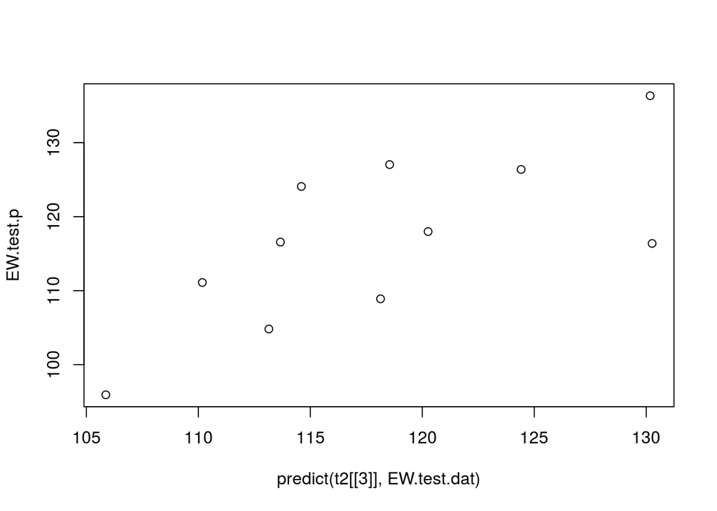

```r
# model 3 lowest MSE
plot(predict(t2[[3]],EW.test.dat),EW.test.p)
```

```r
which.max(results.cor)
```

```
## [1] 10
```

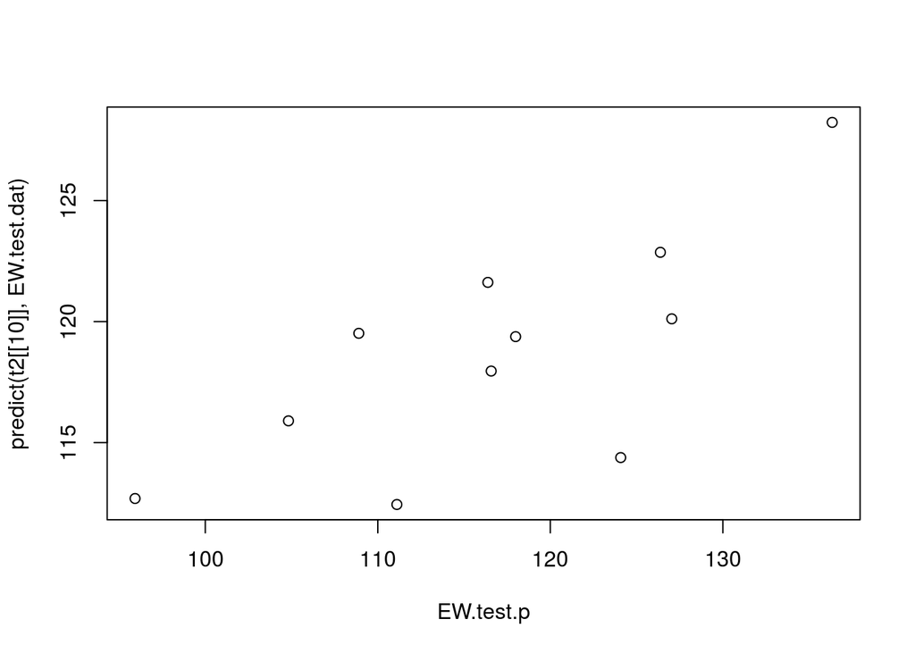

```r
plot(EW.test.p,predict(t2[[10]],EW.test.dat))
```

- Model 3

## 0.6 Caret pt2: Pressure test multiple models ANOVA < .8

- Originally, we just used an adjusted pvalue of 0.05, let’s try others..(Note..we can only try so many different SNP sets becuase the total number of SNPs with adjusted p-values less than 0.8 is 339)
- Execute the models

```r
pval <- .8
LGEP.train.dat <- fam.012.df[which(fam.phenos$fam_id %in% lgep.fams),which(p.adjust(LGEP.anova.scores) < pval)]
colnames(LGEP.train.dat) <- colnames(fam.012.df[,which(p.adjust(LGEP.anova.scores) < pval)])
EW.test.dat <- fam.012.df[which(fam.phenos$fam_id %in% ew.fams),which(p.adjust(LGEP.anova.scores) < pval)]
colnames(EW.test.dat) <- colnames(fam.012.df[,which(p.adjust(LGEP.anova.scores) < pval)])
LGEP.train.p <- fam.phenos$Volume[which(fam.phenos$fam_id %in% lgep.fams)]
EW.test.p <- fam.phenos$Volume[which(fam.phenos$fam_id %in% ew.fams)]
```

```
algorithmList <- c("glmnet","pls","bagEarth","bagEarthGCV","cforest","gaussprRadial","knn","penalized","ranger","RRFglobal","svmLinear2","svmRadialCost")

t2 <- lapply(algorithmList,function(i){
    set.seed(123)
    t2 <- train(y=LGEP.train.p, x=LGEP.train.dat, (i), trControl = tC)
    }
)
save(t2,file = "/mnt/anova.8.LGEP.EW.RData",compress=T)
```

- Extract the results of the models

```r
load("/mnt/anova.8.LGEP.EW.RData")
create.data.table()
```

| Num | Name | R^2 | RMSE | time [s] | Model name |
| --- | --- | --- | --- | --- | --- |
| 1 | glmnet | 0.0558201197105418 | 7.12359396423633 | 4.96500000000015 | glmnet |
| 2 | pls | 0.733656489974832 | 6.98566370064124 | 2.79399999999987 | Partial Least Squares |
| 3 | bagEarth | 0.429635162019542 | 7.95953828658914 | 442.021000000001 | Bagged MARS |
| 4 | bagEarthGCV | 0.727540974290499 | 7.96618875754824 | 161.697999999999 | Bagged MARS using gCV Pruning |
| 5 | cforest | 0.471521520505884 | 11.5884748949937 | 62.0870000000004 | Conditional Inference Random Forest |
| 6 | gaussprRadial | 0.754984862901873 | 9.3406531136805 | 2.38299999999981 | Gaussian Process with Radial Basis Function Kernel |
| 7 | knn | 0.589548707863098 | 10.1826025990172 | 1.14799999999923 | k-Nearest Neighbors |
| 8 | penalized | 0.707653915766474 | 7.08083405079396 | 76.5670000000009 | Penalized Linear Regression |
| 9 | ranger | 0.591434148421016 | 9.03943036207405 | 35.25 | Random Forest |
| 10 | RRFglobal | 0.219189209825862 | 9.09051065012043 | 165.101999999999 | Regularized Random Forest |

[output cut: 2 more lines]

### 0.6.1 Performance on EW test set

```
## geom_path: Each group consists of only one observation. Do you need to
## adjust the group aesthetic?
```

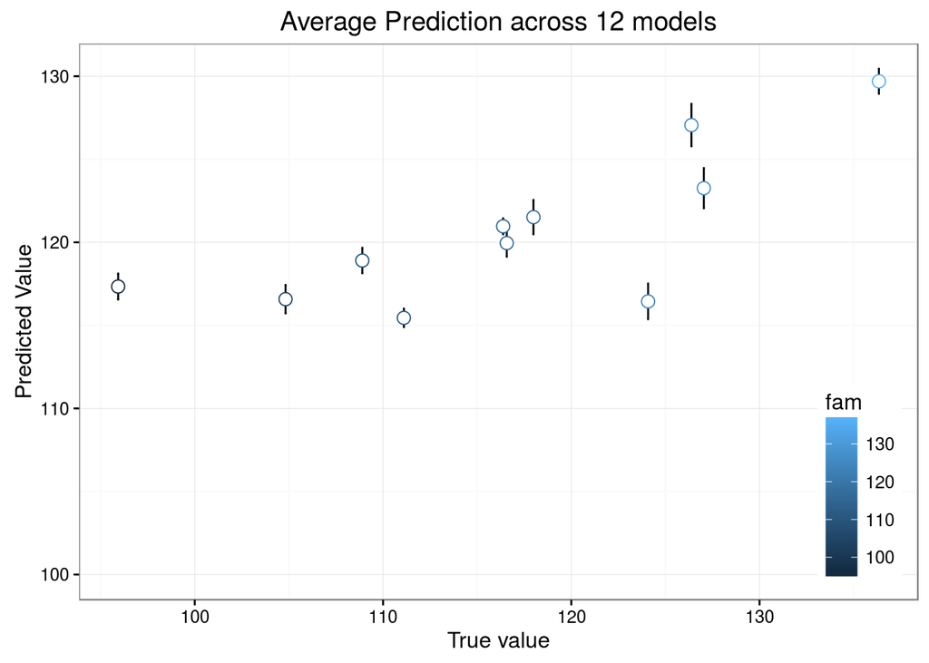

```r
results.cor <- unlist(lapply(t2,function(i){cor(predict(i,EW.test.dat),EW.test.p)}))
results.rmse <- unlist(lapply(t2,function(i){RMSE(pred = predict(i,EW.test.dat),obs = EW.test.p)}))

plot.mean.model.preds()
```

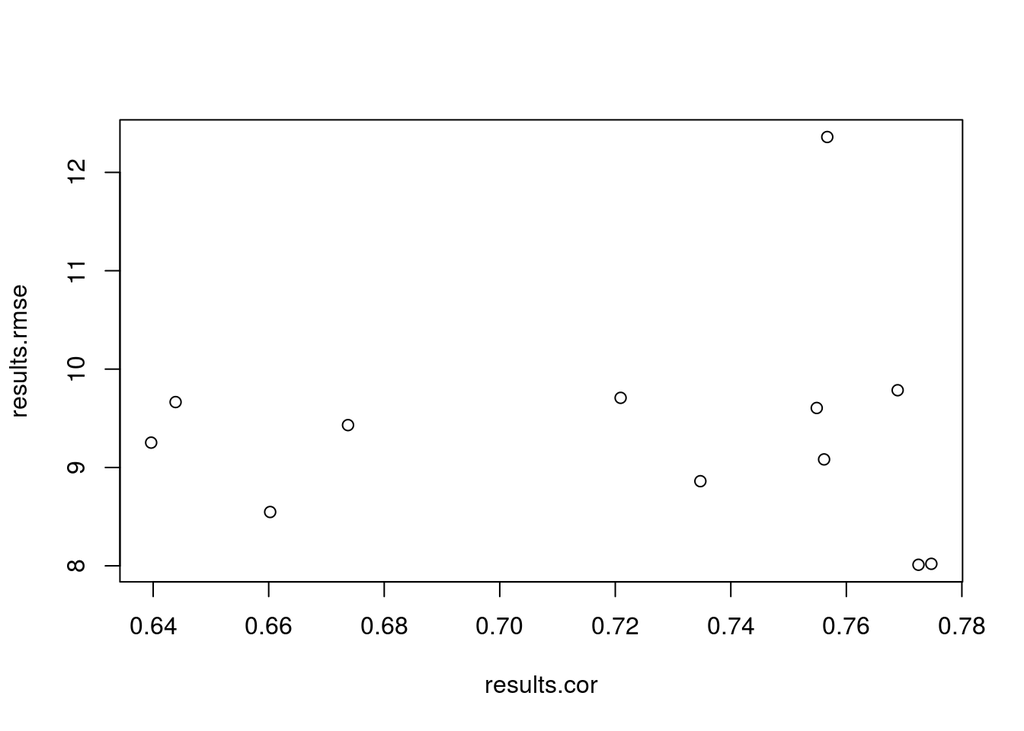

```r
plot(results.cor,results.rmse)
```

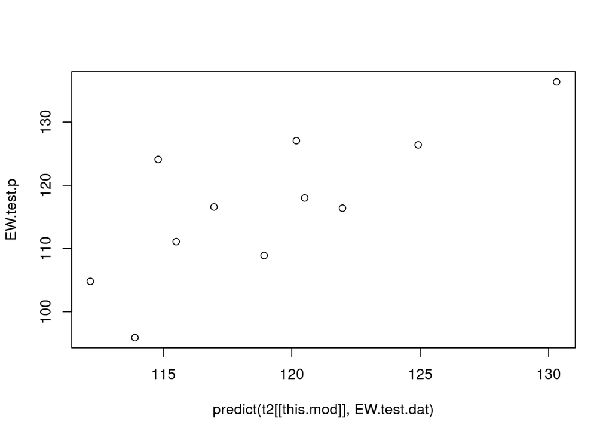

```r
this.mod <- which.min(results.rmse)
# model 3 lowest MSE
plot(predict(t2[[this.mod]],EW.test.dat),EW.test.p)
```

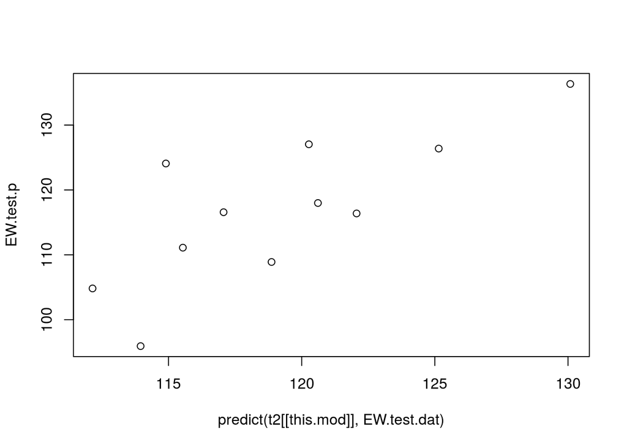

```r
this.mod <- which.max(results.cor)
plot(predict(t2[[this.mod]],EW.test.dat),EW.test.p)
```

## 0.7 Caret pt3: Near zero var and BCV > 3

- We’ve tested the anova_score filtering. Now let’s test SNPs which came out in the near zero var

```r
LGEP.train.dat <- fam.012.df[which(fam.phenos$fam_id %in% lgep.fams),near.zero.bcv3.snps]

colnames(LGEP.train.dat) <- colnames(fam.012.df[,near.zero.bcv3.snps])
EW.test.dat <- fam.012.df[which(fam.phenos$fam_id %in% ew.fams),near.zero.bcv3.snps]
colnames(EW.test.dat) <- colnames(fam.012.df[,near.zero.bcv3.snps])
LGEP.train.p <- fam.phenos$Volume[which(fam.phenos$fam_id %in% lgep.fams)]
EW.test.p <- fam.phenos$Volume[which(fam.phenos$fam_id %in% ew.fams)]
```

```
algorithmList <- c("glmnet","pls","bagEarth","bagEarthGCV","cforest","gaussprRadial","knn","penalized","ranger","RRFglobal","svmLinear2","svmRadialCost")
t2 <- mclapply(algorithmList,function(i){
    set.seed(123)
    t2 <- train(y=LGEP.train.p, x=LGEP.train.dat, (i), trControl = tC)
    },mc.cores=30)
save(t2,file="/mnt/nearzerovar.bcv3.LGEP.EW.RData",compress=T)
```

- Extract the results of the models

```r
load("/mnt/nearzerovar.bcv3.LGEP.EW.RData")
create.data.table()
```

| Num | Name | R^2 | RMSE | time [s] | Model name |
| --- | --- | --- | --- | --- | --- |
| 1 | glmnet | 0.0241385275383198 | 13.2508814705859 | 4.89400000000023 | glmnet |
| 2 | pls | 0.165711316551699 | 13.0121008846067 | 4.50900000000001 | Partial Least Squares |
| 3 | bagEarth | 5.53584885767335e-05 | 13.0610801282894 | 372.229000000001 | Bagged MARS |
| 4 | bagEarthGCV | 0.22988257718257 | 13.0670274187318 | 138.258 | Bagged MARS using gCV Pruning |
| 5 | cforest | 0.0186130104752651 | 14.1473548696281 | 45.4110000000001 | Conditional Inference Random Forest |
| 6 | gaussprRadial | 0.0125788658358775 | 14.2696960259966 | 3.9369999999999 | Gaussian Process with Radial Basis Function Kernel |
| 7 | knn | 0.00139875466331547 | 14.2036970770409 | 2.1929999999993 | k-Nearest Neighbors |
| 8 | penalized | 0.212326161239491 | 11.262045561094 | 22.384 | Penalized Linear Regression |
| 9 | ranger | 0.00340588916090108 | 12.9381656499791 | 40.8970000000008 | Random Forest |
| 10 | RRFglobal | 0.0153899571813107 | 13.1839495889401 | 126.563 | Regularized Random Forest |

[output cut: 2 more lines]

*Performs badly

## 0.8 Caret pt4: BCV > 3 var < .2 SNPs

- We’ve tested the anova_score filtering. Now let’s test those interesting set of SNPs which had a BCV > 3 but variance < .2
- This performs poorly so it’s not ran

```
#interesting.bcv.snps <- which(bcv.snps > 3)
LGEP.train.dat <- fam.012.df[which(fam.phenos$fam_id %in% lgep.fams),interesting.bcv.snps]

colnames(LGEP.train.dat) <- colnames(fam.012.df[,interesting.bcv.snps])
EW.test.dat <- fam.012.df[which(fam.phenos$fam_id %in% ew.fams),interesting.bcv.snps]
colnames(EW.test.dat) <- colnames(fam.012.df[,interesting.bcv.snps])
LGEP.train.p <- fam.phenos$Volume[which(fam.phenos$fam_id %in% lgep.fams)]
EW.test.p <- fam.phenos$Volume[which(fam.phenos$fam_id %in% ew.fams)]
```

```
algorithmList <- c("glmnet","pls","bagEarth","bagEarthGCV")
t2 <- lapply(algorithmList,function(i){
    set.seed(123)
    t2 <- train(y=LGEP.train.p, x=LGEP.train.dat, (i), trControl = tC)
    })
```

- Extract the results of the models

```
create.data.table()
```

*Performs badly

## 0.9 Caret pt5: BCV > 3 & ANOVA < .05

- Here we take a look at SNPs which had a high BCV and an undajusted anova < .05

```r
interesting.bcv.snps <- which(bcv.snps > 3 & LGEP.anova.scores < .05)
LGEP.train.dat <- fam.012.df[which(fam.phenos$fam_id %in% lgep.fams),interesting.bcv.snps]
colnames(LGEP.train.dat) <- colnames(fam.012.df[,interesting.bcv.snps])
EW.test.dat <- fam.012.df[which(fam.phenos$fam_id %in% ew.fams),interesting.bcv.snps]
colnames(EW.test.dat) <- colnames(fam.012.df[,interesting.bcv.snps])
LGEP.train.p <- fam.phenos$Volume[which(fam.phenos$fam_id %in% lgep.fams)]
EW.test.p <- fam.phenos$Volume[which(fam.phenos$fam_id %in% ew.fams)]
```

```
algorithmList <- c("glmnet","pls","bagEarth","bagEarthGCV","cforest","gaussprRadial","knn","penalized","ranger","RRFglobal","svmLinear2","svmRadialCost")
t2 <- mclapply(algorithmList,function(i){
    set.seed(123)
    t2 <- train(y=LGEP.train.p, x=LGEP.train.dat, (i), trControl = tC)
    },mc.cores=30)
save(t2,file="/mnt/bcv3.anova05.LGEP.EW.RData",compress=T)
```

- Extract the results of the models

```r
load("/mnt/bcv3.anova05.LGEP.EW.RData")
create.data.table()
```

| Num | Name | R^2 | RMSE | time [s] | Model name |
| --- | --- | --- | --- | --- | --- |
| 1 | glmnet | 0.00817581384517251 | 11.4315505751498 | 5.90299999999843 | glmnet |
| 2 | pls | 0.790046857371041 | 7.13449435412065 | 14.098 | Partial Least Squares |
| 3 | bagEarth | 0.0045407338651485 | 10.6647420360371 | 1608.067 | Bagged MARS |
| 4 | bagEarthGCV | 0.641757560271996 | 10.6615285802124 | 585.869999999999 | Bagged MARS using gCV Pruning |
| 5 | cforest | 0.0997950306153481 | 13.5495476295853 | 342.109 | Conditional Inference Random Forest |
| 6 | gaussprRadial | 0.356767895528377 | 12.3734844863819 | 10.3739999999998 | Gaussian Process with Radial Basis Function Kernel |
| 7 | knn | 0.293934573556221 | 13.321511799756 | 2.40699999999924 | k-Nearest Neighbors |
| 8 | penalized | 0.153223401748493 | 10.5650419919034 | 236.595000000001 | Penalized Linear Regression |
| 9 | ranger | 0.538782172947277 | 11.0713553916414 | 97.7840000000015 | Random Forest |
| 10 | RRFglobal | 0.0507782626065848 | 11.1027677813226 | 413.548000000001 | Regularized Random Forest |

[output cut: 2 more lines]

- Three models performed relatively well: SVMLinear2, pls, and bagearthGCV

```
## geom_path: Each group consists of only one observation. Do you need to
## adjust the group aesthetic?
```

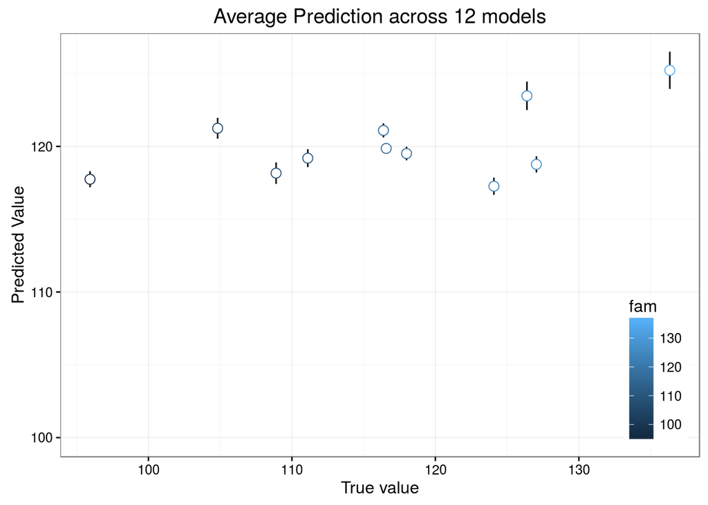

```r
results.cor <- unlist(lapply(t2,function(i){cor(predict(i,EW.test.dat),EW.test.p)}))
results.rmse <- unlist(lapply(t2,function(i){RMSE(pred = predict(i,EW.test.dat),obs = EW.test.p)}))

plot.mean.model.preds()
```

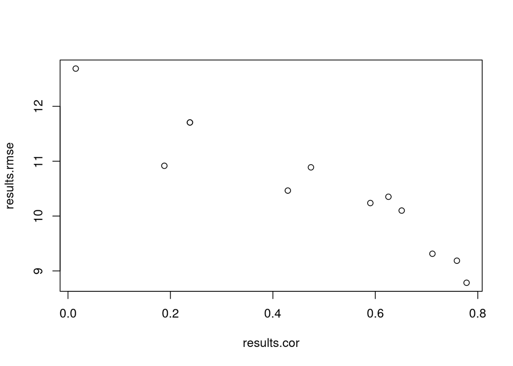

```r
plot(results.cor,results.rmse)
```

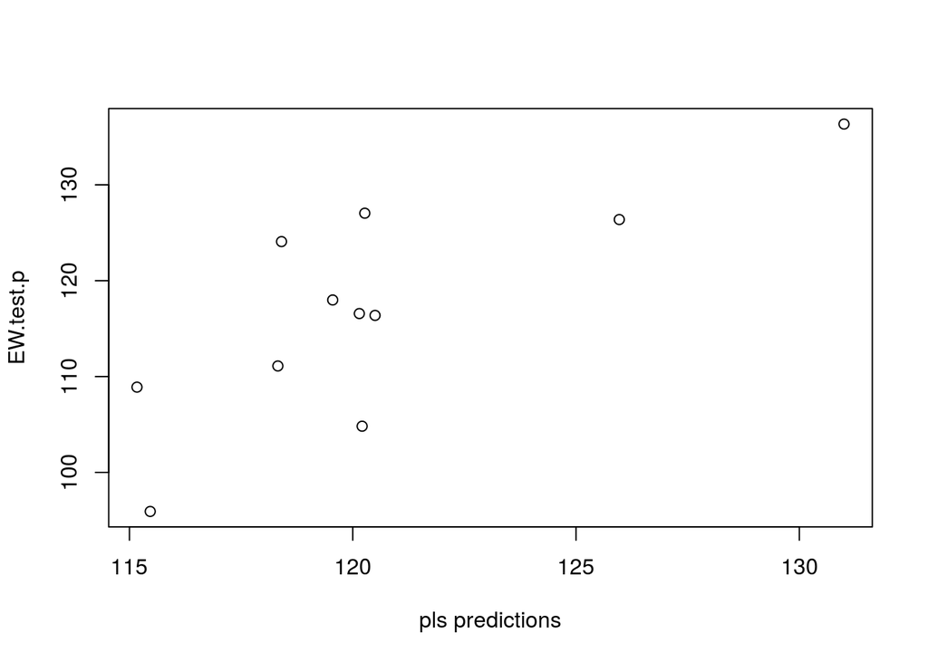

```r
this.mod <- which.min(results.rmse)
plot(predict(t2[[this.mod]],EW.test.dat),EW.test.p,xlab = paste0(algorithmList[this.mod]," predictions"))

this.mod <- which.max(results.cor)
plot(predict(t2[[this.mod]],EW.test.dat),EW.test.p,xlab = paste0(algorithmList[this.mod]," predictions"))
```

[output not shown]

## 0.10 Caret pt6: BCV > 3 & adjusted ANOVA < .05

```
interesting.bcv.snps <- which(bcv.snps > 3 & p.adjust(LGEP.anova.scores) < .05)
LGEP.train.dat <- fam.012.df[which(fam.phenos$fam_id %in% lgep.fams),interesting.bcv.snps]
colnames(LGEP.train.dat) <- colnames(fam.012.df[,interesting.bcv.snps])
EW.test.dat <- fam.012.df[which(fam.phenos$fam_id %in% ew.fams),interesting.bcv.snps]
colnames(EW.test.dat) <- colnames(fam.012.df[,interesting.bcv.snps])
LGEP.train.p <- fam.phenos$Volume[which(fam.phenos$fam_id %in% lgep.fams)]
EW.test.p <- fam.phenos$Volume[which(fam.phenos$fam_id %in% ew.fams)]
```

```
algorithmList <- c("glmnet","pls","bagEarth","bagEarthGCV","cforest","gaussprRadial","knn","penalized","ranger","RRFglobal","svmLinear2","svmRadialCost")
t2 <- mclapply(algorithmList,function(i){
    set.seed(123)
    t2 <- train(y=LGEP.train.p, x=LGEP.train.dat, (i), trControl = tC)
    },mc.cores=30)
save(t2,file="/mnt/bcv3.anova05.LGEP.EW.RData",compress=T)
```

- Extract the results of the models

```
load(file="/mnt/bcv3.anova05.LGEP.EW.RData")
create.data.table()
```

```
results.cor <- unlist(lapply(t2,function(i){cor(predict(i,EW.test.dat),EW.test.p)}))
results.rmse <- unlist(lapply(t2,function(i){RMSE(pred = predict(i,EW.test.dat),obs = EW.test.p)}))

plot.mean.model.preds()

plot(results.cor,df1$x2)
plot(results.cor,results.rmse)
this.mod <- which.min(results.rmse)
plot(predict(t2[[this.mod]],EW.test.dat),EW.test.p,xlab = paste0(algorithmList[this.mod]," predictions"))

this.mod <- which.max(results.cor)
plot(predict(t2[[this.mod]],EW.test.dat),EW.test.p,xlab = paste0(algorithmList[this.mod]," predictions"))
```

## 0.11 Save output

```r
save.image("LGEP_EW_pred.caret.snpsV2.RData",compress=T)
```